# Data Cleaning 1: Data Diagnostics

Camille Beatrice Valera

Kene David Nwosu

Amanda McKinley

Laure Vancauwenberghe

2024-11-21

# 1 Introduction

[figure not shown]

Data cleaning is the process of transforming raw, “messy” data into reliable data that can be properly analyzed. This entails identifying **inaccurate**, **incomplete**, or **improbable** data points and resolving data inconsistencies or errors, as well as renaming variable names to make them more clear and simple to manipulate.

Data cleaning tasks can often be tedious and time-consuming. A common joke among data analysts goes “80% of data science is cleaning the data and the remaining 20% is complaining about cleaning the data.” But data cleaning is an essential step of the data analysis process. A little bit of cleaning at the start of the data analysis process will go a long way to improving the quality of your analyses and the ease with which these analyses can be done. And a range of packages and functions in R can significantly simplify the data cleaning process.

In this lesson, we will begin to look at a typical data cleaning pipeline in R. The cleaning steps covered here are unlikely to be exactly what is needed for your own datasets, but they will certainly be a good starting point.

Let’s get started!

# 2 Learning objectives

- You can diagnose dataset issues that warrant data cleaning through functions such as:
  - `visdat::vis_dat()`
  - `inspectdf::inspect_cat()`
  - `inspectdf::inspect_num()`
  - `gtsummary::tbl_summary()`

# 3 Packages

The packages loaded below will be required for this lesson:

```r
if(!require("pacman")) install.packages("pacman")
pacman::p_load(visdat,
               inspectdf,
               gtsummary,
               tidyverse)
```

# 4 Dataset

- The primary dataset comes from a study conducted in Zambezia, Mozambique.
- It examines individual factors associated with the time until non-adherence to HIV treatment.

```r
non_adherence <- read_csv(here("data/non_adherence_moz.csv"))
```

```
## ──────────────────────────────────────────────────────── Delimiter: "," chr
## (5): Sex, Age_35, Education, Occupation, Civil...status dbl (9): patient_id,
## District, Health unit, Age at ART initiation, WHO statu... lgl (1): NA
```

# 5 Visualizing Missing Data with `visdat::vis_dat()`

- The `vis_dat()` function from the `visdat` package allows us to visualize data types and missing values.
- Each row of the dataset is represented by a line on the plot.
- Let’s create a mock dataset containing 8 patients and their COVID-19 diagnosis and recovery information.

```r
covid_pat <- tribble(
  ~Patient_ID, ~Age, ~Gender,  ~Covid_Strain, ~Exposure,    ~Recovery_Days,
  1,           25,   "Male",   "Alpha",        NA,          10,
  2,           32,   "Female", "Delta",       "Hospital",   15,
  3,           45,   "Male",   "Beta",        "Travel",      7,
  4,           19,   "Female", "Omicron",      NA,          21,
  5,           38,   "Male",   "Alpha",       "Unknown",    14,
  6,           55,   "Female",  NA,           "Community",  19,
  7,           28,   "Female", "Omicron",      NA,           8,
  8,           NA,   "Female", "Omicron",     "Travel",     26
)
covid_pat
```

```
## # A tibble: 8 × 6
##   Patient_ID   Age Gender Covid_Strain Exposure  Recovery_Days
##        <dbl> <dbl> <chr>  <chr>        <chr>             <dbl>
## 1          1    25 Male   Alpha        <NA>                 10
## 2          2    32 Female Delta        Hospital             15
## 3          3    45 Male   Beta         Travel                7
## 4          4    19 Female Omicron      <NA>                 21
## 5          5    38 Male   Alpha        Unknown              14
## 6          6    55 Female <NA>         Community            19
## 7          7    28 Female Omicron      <NA>                  8
## 8          8    NA Female Omicron      Travel               26
```

- Let’s use the `vis_dat()` function to visualize data types and missing values.

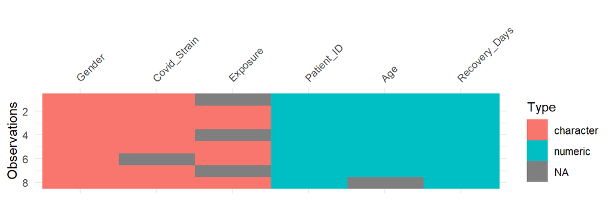

```r
vis_dat(covid_pat)
```

- Different colors are used to illustrate string variables (pink), numeric variables (blue), and missing values (gray).
- Now, let’s look at our real-world dataset, which is much larger and messy.

As a reminder, here is our `non_adherence` dataset.

```r
non_adherence
```

| patient_id | District | Health unit | Sex | Age_35 | Age at ART initiation | Education | Occupation | Civil...status | WHO status at ART initiaiton | BMI_Initiation_Art | CD4_Initiation_Art | regimen.1 | Nr_of_pills_day | NA |
| --- | --- | --- | --- | --- | --- | --- | --- | --- | --- | --- | --- | --- | --- | --- |
| 10037 | 1 | 1 | Male | over 35 | 36 | NA | Truck driver | Stable Union | 1 | 19.42 | NA | 3 | 2 | NA |
| 10537 | 1 | 1 | F | over 35 | 40 | Secondary | Worker | Stable Union | 1 | 24.69 | 107 | 6 | 1 | NA |
| 5489 | 2 | 3 | F | Under 35 | 34.1 | NA | Worker | Widowed | 3 | NA | NA | 6 | 1 | NA |
| 5523 | 2 | 3 | Male | Under 35 | 28.1 | NA | Worker | Stable Union | 1 | NA | NA | 6 | 1 | NA |
| 4942 | 2 | 3 | F | over 35 | 46.9 | University | Superior technician | Stable Union | 3 | NA | NA | 6 | 1 | NA |
| 4742 | 2 | 3 | Male | over 35 | 37.5 | Technical | Lab technician | Stable Union | 2 | NA | NA | 3 | 2 | NA |
| 10879 | 1 | 1 | Male | over 35 | 49.2 | Technical | Water technician | NA | 2 | 23.62 | 139 | 6 | 1 | NA |
| 2885 | 2 | 3 | Male | over 35 | 43.2 | Technical | Agriculture technician | Stable Union | 2 | NA | NA | 3 | 2 | NA |
| 4861 | 2 | 3 | F | over 35 | 50.9 | Technical | Agriculture technician | NA | 1 | NA | NA | 3 | 2 | NA |
| 5180 | 2 | 3 | Male | over 35 | 36.1 | Technical | Agriculture technician | Single | 1 | NA | NA | 6 | 1 | NA |

[output cut: 1403 more lines]

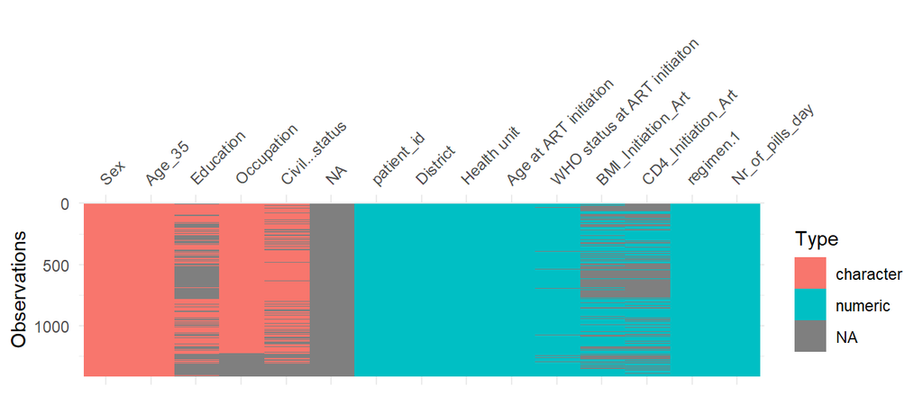

```r
vis_dat(non_adherence)
```

- The `NA` column is completely empty.
- Several variables have a lot of missing values.
- Some variable names are unclear/uncleaned.

*(NOTE: Answers are at the bottom of the page. Try to answer the questions yourself before checking.)*

The following dataset was adapted from a study that investigated missed opportunities for HIV testing among patients newly presenting for HIV care at a Swiss university hospital. The full dataset can be found [here](https://zenodo.org/records/5008340).

```r
missed_ops <- read_csv(here("data/HIV_missed_ops.csv"))
```

Use the `vis_dat()` function to get a visual representation of the data. What potential issues can you spot based on the output?

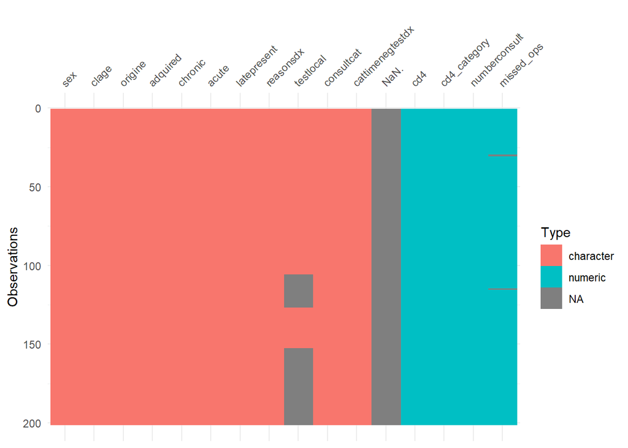

```r
missed_ops <- read_csv(here("data/HIV_missed_ops.csv"))
vis_dat(missed_ops)
```

# 6 Visualization of summary statistics with `inspectdf`

‣ Using the `inspectdf::inspect_cat()` and `inspectdf::inspect_num()` functions to get variable summaries in rich graphical form

‣ `inspect_cat()`: for a summary of categorical variables

```r
inspectdf::inspect_cat(covid_pat)
```

```
## # A tibble: 3 × 5
##   col_name       cnt common  common_pcnt levels
##   <chr>        <int> <chr>         <dbl> <named list>
## 1 Covid_Strain     5 Omicron        37.5 <tibble [5 × 3]>
## 2 Exposure         5 <NA>           37.5 <tibble [5 × 3]>
## 3 Gender           2 Female         62.5 <tibble [2 × 3]>
```

‣ Important information is hidden in the `levels` column

‣ To see this, let’s use the `show_plot()` function with `inspect_cat()`

‣ Use `show_plot()` to visualize categorical distributions

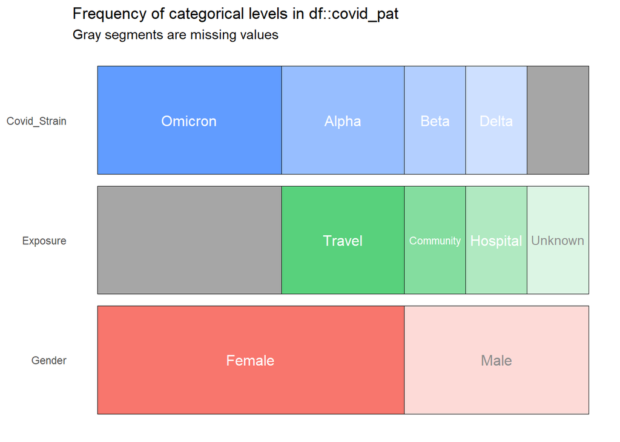

```r
inspect_cat(covid_pat) %>%
 show_plot()
```

‣ Now let’s run this on the `non_adherence` dataset:

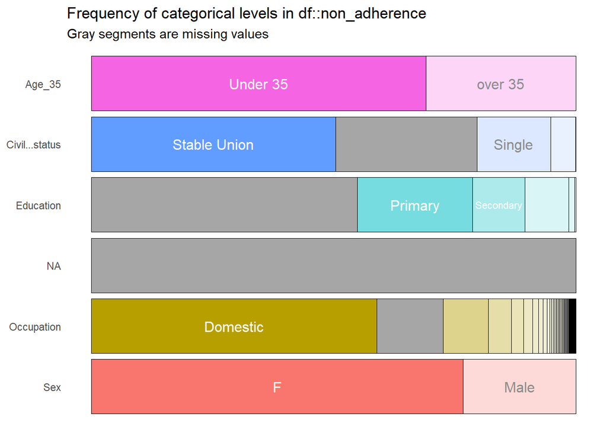

```r
inspect_cat(non_adherence) %>%
 show_plot()
```

‣ We can identify some data issues with categorical variables

- Variable `Age_35`: Inconsistent use of capitalization
- Variable `sex`: Inconsistent naming
- Variable `NA`: Empty, requires cleaning

**inspectdf for categorical variables**

Complete the following code to obtain a visual summary of the categorical variables in the `missed_ops` dataset.

```r
inspect_cat(missed_ops) %>%
  show_plot()
```

How many potential data issues can you spot?

‣ 3

‣ For numeric variables, use `inspect_num()`

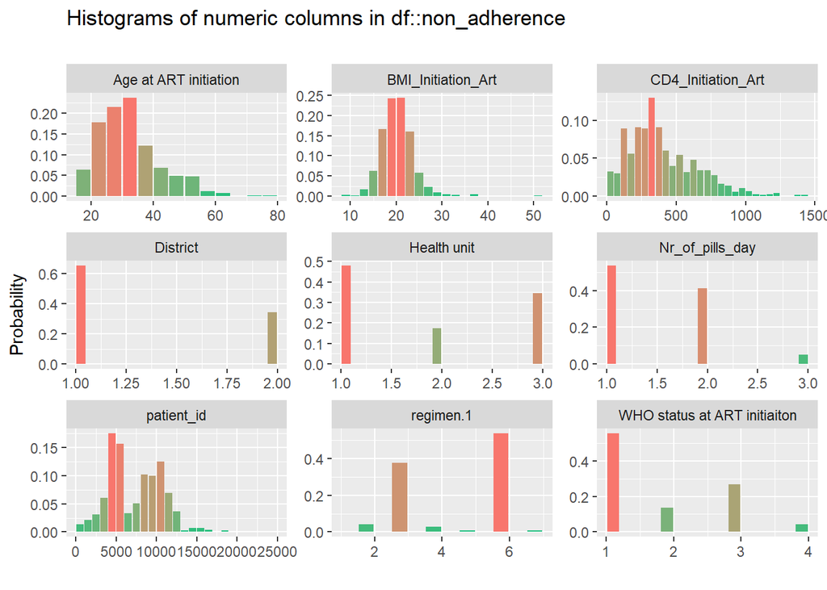

```r
inspect_num(non_adherence) %>%
  show_plot()
```

‣ Common issue: Categorical variables encoded as numeric

Use `inspect_num` to create a histograms of your numeric variables in the `missed_ops` dataset. Are the numeric variable types correct?

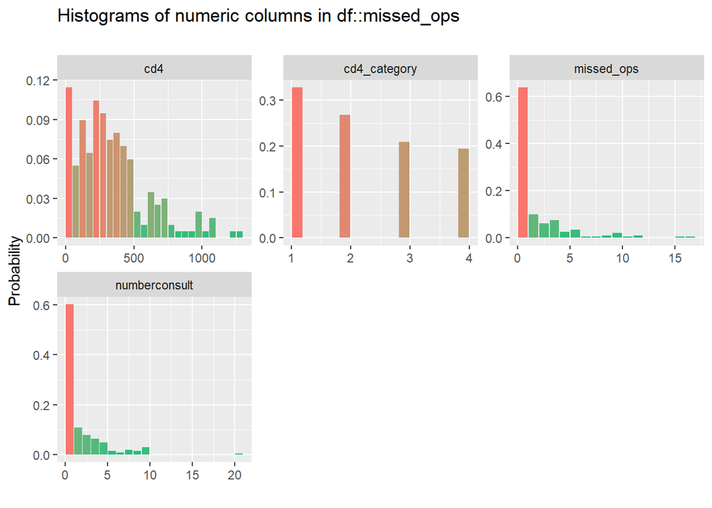

```r
inspect_num(missed_ops) %>%
  show_plot()
```

# 7 Exploring categorical variables with `gtsummary::tbl_summary()`

‣ `tbl_summary()` from `gtsummary` is ideal for obtaining frequencies and percentages of our categorical variables

‣ We will see a tibble format and a snapshot of the output for our `non_adherence` dataset

```r
## NOTE: YOU DO NOT NEED THE AS_TIBBLE() FUNCTION USED IN THE VIDEO
gtsummary::tbl_summary(non_adherence)
```

| **Characteristic** | **N = 1,413**<sup>1</sup> |
| --- | --- |
| patient_id | 7,355 (4,705, 10,098) |
| District |  |
| 1 | 925 (65%) |
| 2 | 488 (35%) |
| Health unit |  |
| 1 | 678 (48%) |
| 2 | 247 (17%) |
| 3 | 488 (35%) |
| Sex |  |
| F | 1,084 (77%) |
| Male | 329 (23%) |
| Age_35 |  |
| over 35 | 437 (31%) |
| Under 35 | 976 (69%) |
| Age at ART initiation | 30 (25, 37) |
| Education |  |
| None | 128 (20%) |
| Primary | 335 (53%) |
| Secondary | 153 (24%) |
| Technical | 17 (2.7%) |
| University | 4 (0.6%) |
| Unknown | 776 |
| Occupation |  |
| Accountant | 1 (<0.1%) |
| Administrator | 1 (<0.1%) |
| Agriculture technician | 3 (0.2%) |
| Artist | 1 (<0.1%) |
| bartender | 1 (<0.1%) |
| Basic service agent | 2 (0.2%) |
| Boat captain | 1 (<0.1%) |

[output cut: 74 more lines]

<sup>1</sup> Median (Q1, Q3); n (%)

‣ The summary includes frequencies and percentages for categorical variables, and the median and interquartile range for numeric variables

Use `tbl_summary()` to output a summary of your `missed_ops` dataset. Can you identify any additional data issues?

```r
gtsummary::tbl_summary(missed_ops)
```

| **Characteristic** | **N = 201**<sup>1</sup> |
| --- | --- |
| sex |  |
| Female | 75 (37%) |
| M | 63 (31%) |
| Male | 63 (31%) |
| clage |  |
| >50 | 33 (16%) |
| 18-29 | 56 (28%) |
| 30-49 | 112 (56%) |
| origine |  |
| Others | 29 (14%) |
| Sub Saharan Africa | 66 (33%) |
| Western World | 106 (53%) |
| adquired |  |
| Heterosexual | 114 (57%) |
| IV drug use | 9 (4.5%) |
| MSM | 68 (34%) |
| Other | 10 (5.0%) |
| chronic | 40 (20%) |
| cd4 | 293 (147, 452) |
| cd4_category |  |
| 1 | 66 (33%) |
| 2 | 54 (27%) |
| 3 | 42 (21%) |
| 4 | 39 (19%) |
| acute |  |
| Not acute | 171 (85%) |
| yes | 30 (15%) |
| latepresent | 106 (53%) |
| reasonsdx |  |
| AIDS defining illness | 21 (10%) |
| Disease for which the prevalence of HIV is >1% | 59 (29%) |
| Epi risk | 21 (10%) |
| Epidemiological risk | 21 (10%) |
| Introduction of immunosuppressive treatment | 1 (0.5%) |
| Patient initiated | 28 (14%) |
| Pregnancy | 14 (7.0%) |
| Suspicion of acute HIV infection | 36 (18%) |
| testlocal |  |
| Anonymous consultation | 26 (20%) |
| CHUV/PMU outpatient | 41 (31%) |
| Primary care physician | 64 (49%) |
| Unknown | 70 |
| numberconsult | 1.00 (0.00, 3.00) |
| consultcat |  |
| >5 previous consultations | 29 (14%) |
| 1-5 previous consultations | 82 (41%) |
| No previous consultation | 90 (45%) |
| cattimenegtestdx |  |
| HIV testing the previous year | 28 (14%) |
| Last HIV test >1 before diagnosis | 54 (27%) |
| No previous HIV testing | 119 (59%) |
| missed_ops | 0.00 (0.00, 3.00) |
| Unknown | 2 |
| NaN. | 0 (NA%) |
| Unknown | 201 |

<sup>1</sup> n (%); Median (Q1, Q3)

# 8 Wrap up!

By familiarizing ourselves with the data, we have been able to identify some potential problems that may need to be addressed before the data are used in an analysis.

The problems we identified in the `non_adherence` dataset were:

- The `NA` variable is a completely empty column, and can be removed.
- Variables names are not clean and must be standardized.
- There are inconsistencies in the way the levels have been coded (e.g., the `Age_35` variable has `Under 35` and `over 35`, the `Sex` variable has `F` and `Male`, and the `Occupation` variable has inconsistent capitalization.)
- Many numeric variables should be coded as factors: `District`, `Health unit`, `WHO status at ART initiaiton`, `regimen.1`, and `Nr_of_pills_day`.

And as you have seen, the actual code needed to do this data exploration is very little; other R developers have done the difficult work for us by building amazing packages to quickly scan datasets and identify issues.

From the next lesson, we will begin to take on these identified issues one by one, starting with the problem of inconsistent, messy variable names.

See you in the next lesson!

# Answer Key

### Q: Spotting data issues with `vis_dat()`

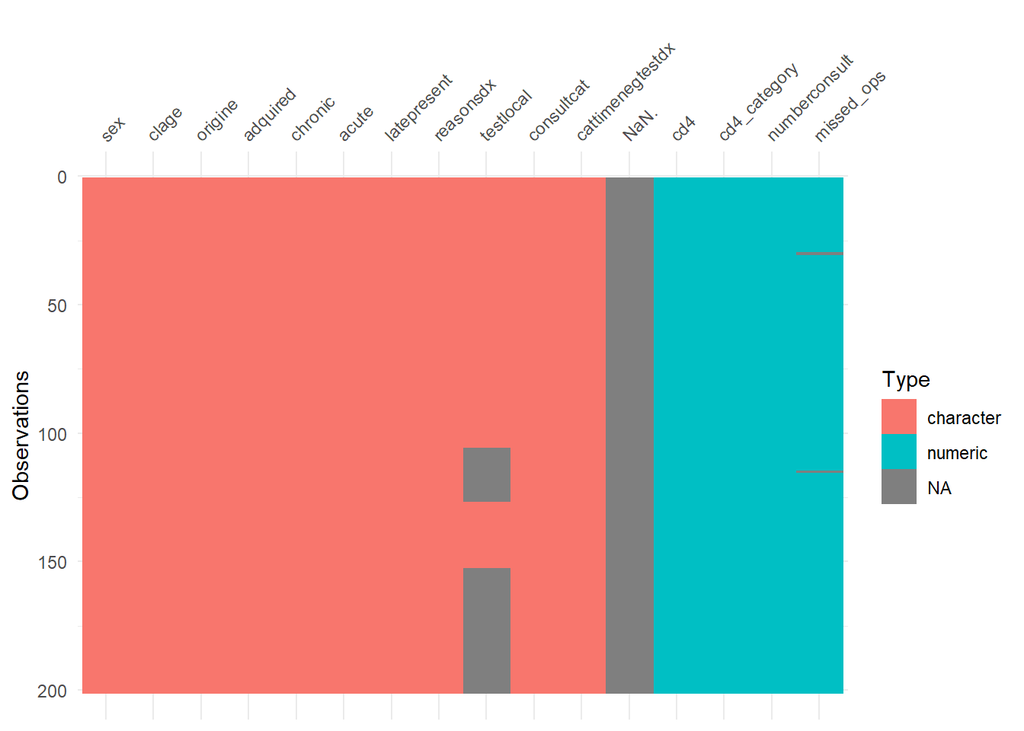

```r
vis_dat(missed_ops)
```

- The column NaN is completely empty

### Q: Spotting data issues with `inspect_cat()`

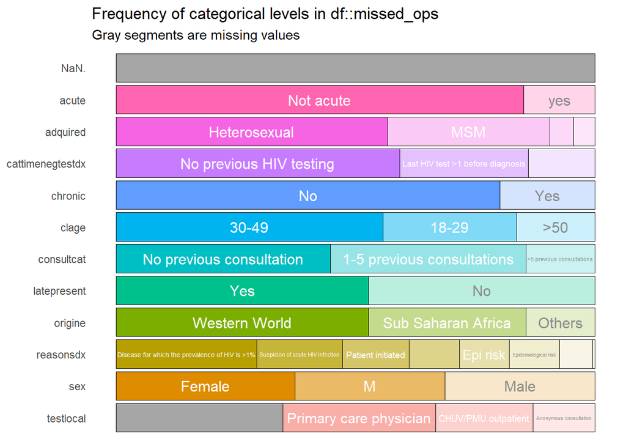

```r
inspect_cat(missed_ops) %>%
  show_plot()
```

- The variable `acute` has 2 levels: `Not acute` and `yes`. This should be standardized.
- The varibale `sex` has 3 levels: `Female`, `Male`, and `M`. The `M` should be changed to `Male`.

### Q: Variable types with `inspect_num()`

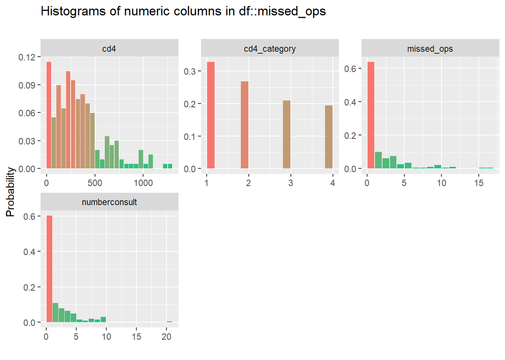

```r
inspect_num(missed_ops) %>%
  show_plot()
```

- The variable `cd4category` should be a factor variabale

### Q: Spotting data issues with `tbl_summary()`

```r
tbl_summary(missed_ops)
```

| **Characteristic** | **N = 201**<sup>1</sup> |
| --- | --- |
| sex |  |
| Female | 75 (37%) |
| M | 63 (31%) |
| Male | 63 (31%) |
| clage |  |
| >50 | 33 (16%) |
| 18-29 | 56 (28%) |
| 30-49 | 112 (56%) |
| origine |  |
| Others | 29 (14%) |
| Sub Saharan Africa | 66 (33%) |
| Western World | 106 (53%) |
| adquired |  |
| Heterosexual | 114 (57%) |
| IV drug use | 9 (4.5%) |
| MSM | 68 (34%) |
| Other | 10 (5.0%) |
| chronic | 40 (20%) |
| cd4 | 293 (147, 452) |
| cd4_category |  |
| 1 | 66 (33%) |
| 2 | 54 (27%) |
| 3 | 42 (21%) |
| 4 | 39 (19%) |
| acute |  |
| Not acute | 171 (85%) |
| yes | 30 (15%) |
| latepresent | 106 (53%) |
| reasonsdx |  |
| AIDS defining illness | 21 (10%) |
| Disease for which the prevalence of HIV is >1% | 59 (29%) |
| Epi risk | 21 (10%) |
| Epidemiological risk | 21 (10%) |
| Introduction of immunosuppressive treatment | 1 (0.5%) |
| Patient initiated | 28 (14%) |
| Pregnancy | 14 (7.0%) |
| Suspicion of acute HIV infection | 36 (18%) |
| testlocal |  |
| Anonymous consultation | 26 (20%) |
| CHUV/PMU outpatient | 41 (31%) |
| Primary care physician | 64 (49%) |
| Unknown | 70 |
| numberconsult | 1.00 (0.00, 3.00) |
| consultcat |  |
| >5 previous consultations | 29 (14%) |
| 1-5 previous consultations | 82 (41%) |
| No previous consultation | 90 (45%) |
| cattimenegtestdx |  |
| HIV testing the previous year | 28 (14%) |
| Last HIV test >1 before diagnosis | 54 (27%) |
| No previous HIV testing | 119 (59%) |
| missed_ops | 0.00 (0.00, 3.00) |
| Unknown | 2 |
| NaN. | 0 (NA%) |
| Unknown | 201 |

<sup>1</sup> n (%); Median (Q1, Q3)

- Example issue: for the variable `reasonsdx`, there are the categories `Epidemiological risk` and `Epi risk` which should be a single category

## References

Some material in this lesson was adapted from the following sources:

- Batra, Neale, et al. The Epidemiologist R Handbook. 2021.*Cleaning data and core functions*. https://epirhandbook.com/en/new_pages/cleaning.html
- Waring E, Quinn M, McNamara A, Arino de la Rubia E, Zhu H, Ellis S (2022). skimr: Compact and Flexible Summaries of Data. https://docs.ropensci.org/skimr/ (website), https://github.com/ropensci/skimr/.

# Contributors

The following team members contributed to this lesson:

- [AMANDA MCKINLEY](https://thegraphcourses.org/members/amckinley/)  
  R Developer and Instructor, the GRAPH Network
- [KENE DAVID NWOSU](https://thegraphcourses.org/members/kendavidn/)  
  Data analyst, the GRAPH Network

  Passionate about world improvement
- [LAURE VANCAUWENBERGHE](https://thegraphcourses.org/members/lolovanco)  
  Data analyst, the GRAPH Network

  A firm believer in science for good, striving to ally programming, health and education